# Data Science

## Review & Future Directions

Alessandro D. Gagliardi

## Agenda

1. Review
   - What we covered
     - Data
     - Science
   - What we didn't
     - Neural Networks
2. Future Directions
   - Types of Data Science
     - 4, 5, 8 types of data scientists
   - From Hacker to Operator
     - Experience
     - Mentorship

# What we covered:

## Data

1. Big Data
   - Hadoop
   - IPython.parallel & StarCluster
2. APIs
   - Twitter
   - JSON
3. Relational Databases
   - SQL
   - 1st, 2nd, and 3rd Normal Form
4. Feature Vectors
   - Data Frames
   - Term-Document Matrices
5. Visualization
   - matplotlib

## Science

1. Regression
   - Linear Regression
   - Decision Trees
2. Classification
   - Logistic Regression
   - k-Nearest Neighbors
3. Dimensionality Reduction
   - Principal Component Analysis
4. Clustering
   - k-Means Clustering

# What we didn't:

- Pig
- Hive, Impala/Presto
- Spark, Shark
- Natural Language Processing
- Network (i.e. Graph) Analysis
- Artificial Neural Networks
- Interactive Visualization (e.g. D3.js)
- ...

## Briefly:

# History of Neural Networks

- The Neuron Doctrine (1899)
- The Perceptron (1943)
- Parallel Distributed Processing (1986)
- Deep Learning

## THE NEURON DOCTRINE ~1899

[figure not shown]

Santiago Ramon y Cajal (1852-1934)

[figure not shown]

- Neurons are the fundamental processing unit of the brain
- Receive input from many sources
- Direct output to many other neurons

## The Model of Neuron (1943)

| Walter Pitts (1923 - 1969) |  | Warren McCulloch (1898 - 1969) |
| --- | --- | --- |

## Parallel Distributed Processing (PDP) (1986)

| David Rumelhart (1942 - 2011) |  | James McClelland (1948 - ) |
| --- | --- | --- |

## Deep Learning

[figure not shown]

Geoffrey Hinton (1947 - )

## What Are Artificial Neural Networks?

(this section lovingly adapted from Vincent Cheung and Kevin Cannons)

- An extremely simplified model of the brain
- Essentially a function approximator
  - Transforms inputs into outputs to the best of its ability
- Composed of many "neurons" that co-operate to perform the desired function

"Neurons," in this case, can be thought of as logistic regressors.

## What Are They Used For?

- Classification
  - Pattern recognition, feature extraction, image matching
- Noise Reduction
  - Recognize patterns in the inputs and produce noiseless outputs
- Prediction
  - Extrapolation based on historical data

## Why Use Neural Networks?

- Ability to learn
  - NN’s figure out how to perform their function on their own
  - Determine their function based only upon sample inputs
- Ability to generalize
  - i.e. produce reasonable outputs for inputs it has not been taught how to deal with

## How Do Neural Networks Work?

- The output of a neuron is a function of the weighted sum of the inputs plus a bias

  $$ Output = f(i_1w_1 + i_2w_2 + \ldots + i_nw_n + bias) $$
- The function of the entire neural network is simply the computation of the outputs of all the neurons
  - An entirely deterministic calculation

## Perceptrons

- First neural network with the ability to learn
- Made up of only input neurons and output neurons
- Input neurons typically have two states: ON and OFF
- Output neurons use a simple threshold activation function
- In basic form, can only solve linear problems
  - Limited applications

[figure not shown]

## How Do Perceptrons Learn?

- Uses supervised training
- If the output is not correct, the weights are adjusted according to the formula:
  - $w_{new} = w_{old} + \alpha(desired - output) \times input$  
    *$\alpha$ is the learning rate*

Example:  
Given input: $[1, 0, 1]$  
and initial weights: $[0.5, 0.2, 0.8]$

Assuming Output Threshold = 1.2  
$1 \times 0.5 + 0 \times 0.2 + 1 \times 0.8 = 1.3 > 1.2$

Assume Output was supposed to be 0 -> update the weights

Assume $\alpha = 1; \\ W_{1_{new}} = 0.5 + 1\times(0-1)\times1 = -0.5 \\ W_{2_{new}} = 0.2 + 1\times(0-1)\times0 = 0.2 \\ W_{3_{new}} = 0.8 + 1\times(0-1)\times1 = -0.2 $

## Multilayer Feedforward Networks

- Most common neural network
- An extension of the perceptron
  - Multiple layers
    - The addition of one or more “hidden” layers in between the input and output layers
  - Activation function is not simply a threshold
    - Usually a sigmoid function
  - A general function approximator
    - Not limited to linear problems
- Information flows in one direction
  - The outputs of one layer act as inputs to the next layer

## XOR Example

[figure not shown]

## Multiple Hidden Layers

[figure not shown]

```python
%load_ext rpy2.ipython
```

```python
%%R
library(nnet)
library(devtools)
source_url('https://gist.github.com/fawda123/7471137/raw/c720af2cea5f312717f020a09946800d55b8f45b/nnet_plot_update.r')
```

```
SHA-1 hash of file is 3e535ef9cbcad648f0fffb89a8879e12c09be1e7
```

# Example: Unsupervised Learning

```python
%%R
eight <- data.frame(X1=c(1, rep(0, 7)), X2=c(0,1,rep(0,6)), X3=c(0,0,1,rep(0,5)), X4=c(0,0,0,1,rep(0,4)),
                    X5=c(rep(0,4),1,0,0,0), X6=c(rep(0,5),1,0,0), X7=c(rep(0,6),1,0), X8=c(rep(0,7),1))
eight
```

```
  X1 X2 X3 X4 X5 X6 X7 X8
1  1  0  0  0  0  0  0  0
2  0  1  0  0  0  0  0  0
3  0  0  1  0  0  0  0  0
4  0  0  0  1  0  0  0  0
5  0  0  0  0  1  0  0  0
6  0  0  0  0  0  1  0  0
7  0  0  0  0  0  0  1  0
8  0  0  0  0  0  0  0  1
```

```python
%%R
library(nnet)
eight.net <- nnet(x = eight, y = eight, size = 3)
```

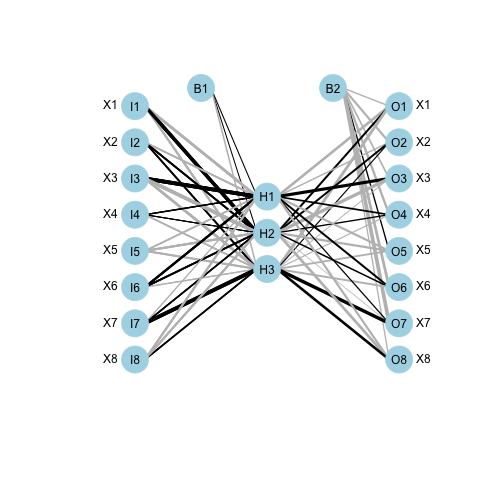

```python
%R plot(eight.net)
```

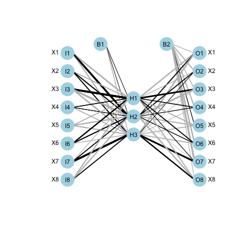

```python
%R plot(eight.net)
```

```python
%%R
hidden_sums <- function(i) {
    return(c(sum(plot.nnet(eight.net,wts.only=T)[['hidden 1 1']][c(1,i+1)]),
             sum(plot.nnet(eight.net,wts.only=T)[['hidden 1 2']][c(1,i+1)]),
             sum(plot.nnet(eight.net,wts.only=T)[['hidden 1 3']][c(1,i+1)])))
}
t(sapply(c(1:8), hidden_sums))
```

```
          [,1]       [,2]        [,3]
[1,] -74.27716  153.52545 -114.914604
[2,] -29.45131   67.34601   11.994022
[3,] 178.62245 -127.33697 -141.800951
[4,]  46.40392   26.41822  -89.102208
[5,] -21.25470  -54.01132 -106.480410
[6,]  89.39570   68.24173  -68.737356
[7,]  13.38731   52.86827  118.707216
[8,] -44.90708  -50.92681    5.174338
```

```python
%%R
t(sapply(c(1:8), hidden_sums) > 1) * 1
```

```
     [,1] [,2] [,3]
[1,]    0    1    0
[2,]    0    1    1
[3,]    1    0    0
[4,]    1    1    0
[5,]    0    0    0
[6,]    1    1    0
[7,]    1    1    1
[8,]    0    0    1
```

# Future Directions

[figure not shown]

## Categories of data scientists

*(according to [Vincent Granville](http://www.datasciencecentral.com/profiles/blogs/six-categories-of-data-scientists))*

- Those strong in **statistics**: they are expert in statistical modeling, experimental design, sampling, clustering, data reduction, confidence intervals, testing, modeling, predictive modeling and other related techniques.
- Those strong in **mathematics**: NSA or defense/military, astronomers, and operations research people doing analytic business optimization (inventory management and forecasting, pricing optimization, supply chain, quality control, yield optimization).
- Those strong in **data engineering**, Hadoop, database/memory/file systems optimization and architecture, API's, Analytics as a Service, optimization of data flows, data plumbing.
- Those strong in **machine learning** / computer science (algorithms, computational complexity)
- Those strong in **business**, ROI optimization, decision sciences, involved in some of the tasks traditionally performed by business analysts in bigger companies (dashboards design, metric mix selection and metric definitions, ROI optimization, high-level database design)
- Those strong in production code development, **software engineering** (they know a few programming languages)
- Those strong in **visualization**
- Those strong in GIS, **spatial data**, data modeled by graphs, graph databases
- Those strong in a few of the above.

*(according to [Tomasz Tunguz](https://www.linkedin.com/today/post/article/20131002174328-4444200-which-of-the-five-types-of-data-science-does-your-startup-need))*

1. **Quantitative, exploratory** data scientists tend to have PhDs and use *theory* to understand behavior. Varian’s team researches the advertiser dynamics within the ads auction and compares those dynamics to theoretical auction *models* like theVickery auction. By combining theory and exploratory research, these data scientists improve products.
2. **Operational** data scientists often work in the *finance, sales or operations* teams at Google. In the AdSense ops . . . a star data analyst who each week would discuss our team’s performance: our email response times, the satisfaction scores of our publishers, and changes in publisher behavior by segment. His work provided a feedback loop to improve the team’s tactics and efficiency.
3. **Product** data scientists tend to belong to product management or engineering. PMs and engineers *sift through logs and analysis tools to understand the way users interact* a product and leverage that knowledge to refine the product. At Google, the ads quality team analyzed user clicks data to improve ad targeting.
4. **Marketing** data scientists *segment* the user base, *evaluate* the performance of advertising campaigns, *match* product features to customer segments, and *design* content marketing campaigns. The marketing data scientist creates awareness and leads for the sales team, helping generate revenue.
5. **Research** data scientists create *insights as a product*. Nate Silver is arguably the most famous of them. Silver’s work doesn’t influence a product; the analysis is the product itself. Sometimes the data science leads to a thought leadership whitepaper, or a blog post, or a financial report.

*(emphasis mine)*

*(according to [Harlan D. Harris](http://strata.oreilly.com/2013/06/theres-more-than-one-kind-of-data-scientist.html))*

- **Data Businesspeople** are the product and profit-focused data scientists. They’re leaders, managers, and entrepreneurs, but with a technical bent. A common educational path is an engineering degree paired with an MBA.
- **Data Creatives** are eclectic jacks-of-all-trades, able to work with a broad range of data and tools. They may think of themselves as artists or hackers, and excel at visualization and open source technologies.
- **Data Developers** are focused on writing software to do analytic, statistical, and machine learning tasks, often in production environments. They often have computer science degrees, and often work with so-called “big data”.
- **Data Researchers** apply their scientific training, and the tools and techniques they learned in academia, to organizational data. They may have PhDs, and their creative applications of mathematical tools yields valuable insights and products.

[figure not shown]

*(according to [Brendan Tierney](http://www.oralytics.com/2013/03/type-i-and-type-ii-data-scientists.html))*

1. **The Type I Data Scientist** specializes in...
   - Statisticians
   - Data Miners
   - Predictive Modellers
   - Machine Learning
   - Data Warehousing
   - Business Intelligence & Visualization
   - Big Data
   - R / Oracle / SAS / SPSS / etc.
2. **The Type II Data Scientist** approaches the types of problems that organisations are facing in a different way. They will concentrate on the business goals and business problems that the organisation are facing. Based on these they will identify what the data scientist project will focus on, ensuring that there is a measurable outcome and business goal. The Type II Data Scientist will be a good communicator, being able to translate between the business problem and the technical environment necessary to deliver what is needed. During the project the data science team will discovery various insight about the data. The Type II Data Scientist will prioritise these and feed them back to the various business units. Some of these insights can range from something new, verifying business knowledge beliefs, areas where better data capture is needed, improvements in applications, etc.

[figure not shown]

## Types Levels of Data Science

*(according to [Steve Jones](http://service-architecture.blogspot.com/2014/03/what-are-types-of-data-scientist.html))*

1. **Data Science Bluffers** They are the people who get a spreadsheet with a bunch of data, apply a very basic statistical function and claim 'Hey its Data Science'.
2. **Data Hackers** *'the one eyed man in the kingdom of the blind'*...people with a bit of skill, maybe a bit of training, but they aren't at the level of sophistication of an operator...don't mistake knowing how to apply one Machine Learning technique for actual knowledge.
3. **Data Operators** *or* **Resident Data Scientists** take predefined algorithms, statistical or machine learning, and then apply them to a specific company scenario and most crucially keep the parameters up to date so the algorithm continues to perform.
4. **Data Magicians** normally have mathematical or physics centric PhDs (often several), often focused in specific areas such as fluid dynamics, economics or super specific such as wind-turbines... The reason its science is because its testable and provable. They can show that their algorithm would have produced 5% improvement in performance over the past 5 years, and as it moves forward show how their approach has made a difference to the performance of a business.

You are probably at the "Data Hacker" level right now and should strive to become an Operator or Resident Data Scientist.  
(I'm at the Operator level and striving to become a Magician.)

Q. How do I go from *Data Hacker* to a *Data Operator* or *Resident Data Scientist*?

1. *Experience* - Challenge yourself with projects just outside of your ability and learn the techniques you need to achieve it.
2. *Mentorship* - Ideally someone in your organization invested in your growth.
   - Also: the greater Data Science community

[figure not shown]

## Tools to keep an eye on:

- D3.js
- Spark
- Julia

## Useful Languages (besides Python, R, and SQL)

- Julia
- Scala
- Pig
- JavaScript
- Java (sorry)